[figure not shown]

[OHI British Columbia](http://www.ohibc.org/) | [OHI Science](http://ohi-science.org) | [Citation policy](https://github.com/OHI-Science/ohiprep/releases)

# OHIBC Howe Sound goal prep: Iconic Species

Compiled on Thu Dec 1 10:55:27 2016 by ohara

# 1 Summary: OHIBC Howe Sound Species and Iconic Species

This script prepares scores (status and trend) for species richness in British Columbia’s Howe Sound region. Spatial data from IUCN and Aquamaps is combined with extinction risk information from IUCN and conservation rank info based on province-level NatureServe categories.

Because of the small scale of Howe Sound, neither Species nor Iconic Species goals use any area weighting. Instead, ICO and SPP status is based upon a simple average of species health for species found within the Howe Sound region.

From Halpern et al (2012):

> The target for the Species sub-goal is to have all species at a risk status of Least Concern. We scaled the lower end of the biodiversity goal to be 0 when 75% species are extinct, a level comparable to the five documented mass extinctions and would constitute a catastrophic loss of biodiversity. The Status of assessed species was calculated as the area- and threat status-weighted average of the number of threatened species within each 0.5 degree grid cell.

**Mean risk status for Howe Sound:**

$$\bar{R} = \frac{\displaystyle\sum_{species}(Risk)}{n_{spp}}$$

where:

- $X_{ICO}$ is Species goal status
- $\bar{R}$ is mean extinction risk for identified species within Howe Sound (different subsets for ICO and SPP)
- *Risk* is scaled value for species extinction risk category, based on:
  - ‘LC’ = 0.0, ‘NT’ = 0.2, ‘VU’ = 0.4, ‘EN’ = 0.6, ‘CR’ = 0.8, ‘EX’ = 1.0
- ICO trend is calculated as the linear trend of the average extinction risk categories over time.

# 2 Data sources

AquaMaps

- From http://www.aquamaps.org/main/home.php: “AquaMaps are computer-generated predictions of natural occurrence of marine species, based on the environmental tolerance of a given species with respect to depth, salinity, temperature, primary productivity, and its association with sea ice or coastal areas.”
- Citation: Kaschner, K., J. Rius-Barile, K. Kesner-Reyes, C.Garilao, S.O. Kullander, T. Rees and R. Froese (2013). AquaMaps: Predicted range maps for aquatic species. World wide web electronic publication, www.aquamaps.org, Version 08/2013.

IUCN Red List spatial data: species range map shapefiles

- Species range map shapefiles downloaded from: http://www.iucnredlist.org/technical-documents/spatial-data
- Citation: IUCN 2014. The IUCN Red List of Threatened Species. Version 2014.1. http://www.iucnredlist.org. Downloaded on 21 September 2015.

IUCN Red List species index: list of all IUCN red list species, incl IUCN species ID and extinction risk category

- Extinction risk categories downloaded from: http://api.iucnredlist.org/index/all.csv
- Habitat and subpopulation information, by species, scraped from: http://www.iucnredlist.org/details//0
- Citation: IUCN 2015. The IUCN Red List of Threatened Species. Version 2015-3. http://www.iucnredlist.org. Downloaded on 9 September 2015.

NatureServe/BC CDC conservation rank info from BC Species and Ecosystems Explorer:

- BC Conservation Data Centre: http://www.env.gov.bc.ca/atrisk/toolintro.html
- NatureServe conservation status: http://explorer.natureserve.org/ranking.htm#global
- Citation: B.C. Conservation Data Centre. 2013. BC Species and Ecosystems Explorer. B.C. Ministry of Environment, Victoria B.C. Available: http://a100.gov.bc.ca/pub/eswp/. Downloaded on 3 August 2015.

# 3 Methods

## 3.1 Define assessment region

Using OHIBC Howe Sound region polygon, determine 0.5° raster cells corresponding to the region.

## 3.2 Identify Howe Sound-specific species and info

The goal_prep_spp_howesound.Rmd script creates a time series of species info for all species present within Howe Sound, as determined by AquaMaps and IUCN.

## 3.3 Identify Howe Sound iconic species

Combining global ICO list with CORI-supplied Howe Sound ICO list, we come up with a master list of all iconic species within the Howe Sound region.

### 3.3.1 Howe Sound Iconic Species

The 40 species considered Iconic for the Howe Sound assessment:

Alopias vulpinus, Ammodytes hexapterus, Ardea herodias, Balaenoptera acutorostrata, Balaenoptera borealis, Balaenoptera musculus, Balaenoptera physalus, Brachyramphus marmoratus, Branta canadensis, Carcharodon carcharias, Cetorhinus maximus, Clupea pallasii, Delphinus delphis, Dermochelys coriacea, Eretmochelys imbricata, Eschrichtius robustus, Galeocerdo cuvier, Gavia immer, Globicephala macrorhynchus, Grampus griseus, Haliaeetus leucocephalus, Hypomesus pretiosus, Isurus paucus, Kogia breviceps, Lagenorhynchus obliquidens, Megaptera novaeangliae, Mesoplodon densirostris, Oncorhynchus gorbuscha, Oncorhynchus kisutch, Oncorhynchus nerka, Oncorhynchus tshawytscha, Orcinus orca, Phoca vitulina, Phocoena phocoena, Physeter macrocephalus, Prionace glauca, Pseudorca crassidens, Stenella coeruleoalba, Thaleichthys pacificus, Ziphius cavirostris

**NOTE**: Not all these species have IUCN red list assessments or NatureServe assessments.

### 3.3.2 Howe Sound Iconic Species info

Most recent year only:

|  | am_sid | iucn_sid | spatial_source | sciname | cat_score | pr_score | trend_score | cat_ts | cat_txt | cat_ts_score |
| --- | --- | --- | --- | --- | --- | --- | --- | --- | --- | --- |
| 1 | ITS-Mam-180524 | 2474 | iucn | Balaenoptera acutorostrata | 0.2 | 0.2 | 0 | LC | Least Concern | 0 |
| 2 | ITS-Mam-180526 | 2475 | iucn | Balaenoptera borealis | 1 | 1 |  | EN | Endangered | 0.6 |
| 3 | ITS-Mam-180528 | 2477 | iucn | Balaenoptera musculus | 0.8 | 0.8 | 0.5 | EN | Endangered | 0.6 |
| 4 | ITS-Mam-180527 | 2478 | iucn | Balaenoptera physalus | 0.6 | 0.6 |  | EN | Endangered | 0.6 |
| 5 | Fis-23071 | 3855 | am | Carcharodon carcharias | 0.4 |  |  | VU | Vulnerable | 0.4 |
| 6 | Fis-22747 | 4292 | am | Cetorhinus maximus | 0.4 |  | -0.5 | VU | Vulnerable | 0.4 |
| 7 | ITS-Mam-180438 | 6336 | iucn | Delphinus delphis | 0 |  |  | LC | Least Concern | 0 |
| 8 | Rep-5181 | 8005 | iucn | Eretmochelys imbricata | 0.8 |  | -0.5 | CR | Critically Endangered | 0.8 |
| 9 | ITS-Mam-180521 | 8097 | iucn | Eschrichtius robustus | 0.4 | 0.4 | 0 | LC | Least Concern | 0 |
| 10 | ITS-Mam-180466 | 9249 | iucn | Globicephala macrorhynchus | 0.3 |  |  | CD | Lower Risk/conservation dependent | 0.3 |

[output cut: 20 more lines]

Howe Sound iconic species status and trend

| year | mean_cat_ts | rgn_id | status | trend |
| --- | --- | --- | --- | --- |
| 2016 | 0.3066667 | 1 | 0.6933333 | 0.0001377 |
| 2015 | 0.2909091 | 1 | 0.7090909 | 0.0001377 |
| 2014 | 0.2909091 | 1 | 0.7090909 | 0.0001377 |
| 2013 | 0.2909091 | 1 | 0.7090909 | 0.0001377 |
| 2012 | 0.2909091 | 1 | 0.7090909 | 0.0001377 |
| 2011 | 0.2909091 | 1 | 0.7090909 | 0.0001377 |
| 2010 | 0.2909091 | 1 | 0.7090909 | 0.0001377 |
| 2009 | 0.2909091 | 1 | 0.7090909 | 0.0001377 |
| 2008 | 0.2909091 | 1 | 0.7090909 | 0.0001377 |
| 2007 | 0.3000000 | 1 | 0.7000000 | 0.0001377 |
| 2006 | 0.3000000 | 1 | 0.7000000 | 0.0001377 |

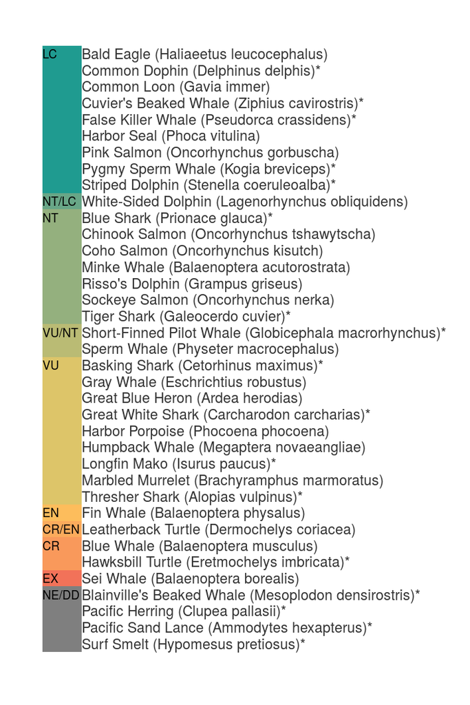

# 4 Provenance

- *Run ID: 9 (3dd7320); run tag: “standard run”*
- *Run elapsed time: 33.871 seconds; run memory usage: NA MB*
- *System info:*
  - *System: Linux, Release: 4.4.0-45-generic. Machine: x86_64. User: ohara.*
  - *R version: R version 3.3.2 (2016-10-31), Platform: x86_64-pc-linux-gnu, Running under: Ubuntu 14.04.5 LTS.*
  - *Attached base packages: stats, graphics, grDevices, utils, datasets, methods, base*
  - *Other attached packages: provRmd_0.1.1, maptools_0.8-39, sp_1.2-3, RColorBrewer_1.1-2, tmap_1.6-1, stringr_1.1.0, dplyr_0.5.0, purrr_0.2.2, readr_1.0.0, tidyr_0.6.0, tibble_1.2, ggplot2_2.1.0, tidyverse_1.0.0*

[figure not shown]

| sequence | file_name | parent_chunk | file_dir | filetype | uncomm_chgs | commit_hash_short |
| --- | --- | --- | --- | --- | --- | --- |
| 0 | goal_prep_ico_howesound.Rmd | provenance | ~/github/ohibc/prep/spp_ico/vHS | parent_script | True | 103095e |
| 0 | goal_prep_ico_howesound.Rmd#generate_ico_list | generate_ico_list | ~/github/ohibc/prep/spp_ico/vHS | parent_chunk | True | 103095e |
| 0 | goal_prep_ico_howesound.Rmd#plot_ico_by_cat | plot_ico_by_cat | ~/github/ohibc/prep/spp_ico/vHS | parent_chunk | True | 103095e |
| 0 | goal_prep_ico_howesound.Rmd#provenance | provenance | ~/github/ohibc/prep/spp_ico/vHS | parent_chunk | True | 103095e |
| 0 | goal_prep_ico_howesound.Rmd#save_howe_sound_status_trend | save_howe_sound_status_trend | ~/github/ohibc/prep/spp_ico/vHS | parent_chunk | True | 103095e |
| 0 | goal_prep_ico_howesound.Rmd#setup | setup | ~/github/ohibc/prep/spp_ico/vHS | parent_chunk | True | 103095e |
| 0 | goal_prep_ico_howesound.Rmd#setup_region-to-cell_lookup | setup_region-to-cell_lookup | ~/github/ohibc/prep/spp_ico/vHS | parent_chunk | True | 103095e |
| 0 | goal_prep_ico_howesound.Rmd#summarize_ico | summarize_ico | ~/github/ohibc/prep/spp_ico/vHS | parent_chunk | True | 103095e |
| 1 | spp_fxn.R | setup | ~/github/ohibc/prep/spp_ico/vHS | sourced_script | False | d717cff |
| 2 | howe_sound_rgn.shp | setup_region-to-cell_lookup | ~/github/ohibc/prep/spatial | input | False | 3fee1de |

[output cut: 14 more lines]